# IE48A Group Project

RAMMSTEIN

02 09 2020

# Explanatory Data Analysis

## Load Libraries

```r
library(dplyr)
library(ggplot2)
library(lubridate)
library(tidyverse)
library(tidyr)
library(kableExtra)
library(openxlsx)
library(readxl)
```

## Download the Data

First of all, the two excel files for male and female are downloaded from [TUIK site](https://biruni.tuik.gov.tr/medas/?kn=112&locale=tr) and remerged in order to import the files into R environment.

The excel files (Male and Female) then uploaded to the group’s Github directory

```r
# Male data
male=tempfile(fileext=".xlsx")
download.file("https://github.com/pjournal/boun01g-r-ammstein/blob/gh-pages/Marriage_data_of_male_in_Turkey.xlsx?raw=TRUE",destfile=male,mode='wb')
MaleRawData = read.xlsx(male)
file.remove(male)
```

```
## [1] TRUE
```

```r
# Female data
female=tempfile(fileext=".xlsx")
download.file("https://github.com/pjournal/boun01g-r-ammstein/blob/gh-pages/Marriage_data_of_female_in_Turkey.xlsx?raw=TRUE",destfile=female,mode='wb')
FemaleRawData = read.xlsx(female)
file.remove(female)
```

```
## [1] TRUE
```

## Preprocessing the Data

Firstly, In order to have meaningfull data, we remove all unnecessary information in the first columns by sub() function.

```r
MaleOrganized<- sub(pattern = "Erkeğin yaş grubu:", replacement = "", x = MaleRawData[,1])
MaleOrganized2<-sub(pattern = "ve Erkeğin eğitim durumu:", replacement = "", x = MaleOrganized)
MaleOrganized3<-data.frame(MaleOrganized2, ncol=1, byrow=TRUE) %>% select(A=MaleOrganized2)
```

Then, we formed two new columns with seperating the first columns according to age groups, and education levels.

```r
MaleOrganized4<-MaleOrganized3 %>% mutate(A = str_replace(A, "\\s", "|")) %>%
          separate(A, into = c("first", "rest"), sep = "\\|")
```

We created a data frame with cbind() function, renamed all columns, and also added a new column named “Gender”.

```r
MaleOrganized5<-cbind(MaleOrganized4,MaleRawData[,2:3]) %>%
                rename( AgeGroup=first,EducationLevel=rest,Year=A2,NbOfFirstMarriages=A3) %>%
                mutate(Gender="Male")
```

We did these steps for FemaleRawData as well.

```r
FemaleOrganized<- sub(pattern = "Kadının yaş grubu:", replacement = "", x = FemaleRawData[,1])
FemaleOrganized2<-sub(pattern = "ve Kadının eğitim durumu:", replacement = "", x = FemaleOrganized)
FemaleOrganized3<-data.frame(FemaleOrganized2, ncol=1, byrow=TRUE) %>% select(A=FemaleOrganized2)
FemaleOrganized4<-FemaleOrganized3 %>% mutate(A = str_replace(A, "\\s", "|")) %>%
          separate(A, into = c("first", "rest"), sep = "\\|")

FemaleOrganized5<-cbind(FemaleOrganized4,FemaleRawData[,2:3]) %>%
                rename( AgeGroup=first,EducationLevel=rest,Year=A2,NbOfFirstMarriages=A3) %>%
                mutate(Gender="Female")
```

As can be expected, these “Gender” columns’s observations are printed as “Male” for Male Data, and “Female” for Female Data. Then, we united both male and female datas by using rbind() function, and assigned to a new data frame named “rawDataOrganized”. Then, we have converted characters into factors.

```r
rawDataOrganized<-rbind(MaleOrganized5,FemaleOrganized5)

rawDataOrganized[,1]<-as.factor(rawDataOrganized[,1])
rawDataOrganized[,2]<-as.factor(rawDataOrganized[,2])
rawDataOrganized[,5]<-as.factor(rawDataOrganized[,5])
```

Finally, we have the processed data which includes 5 columns and 1709 rows. The columns are explained at below:

- AgeGroup: There are 10 age groups consists of 4 years age period range,such as 16-19, and plus one unknown group
- EducationLevel: There are 7 levels of education levels and an unknown level
- Year: Year between 2009 and 2019
- NbOfFirstMarriages: Total number of first marriages in given time period
- Gender: Male or Female

```r
glimpse(rawDataOrganized)
```

```
## Rows: 1,709
## Columns: 5
## $ AgeGroup           <fct> 16-19, 16-19, 16-19, 16-19, 16-19, 16-19, 16-19,...
## $ EducationLevel     <fct> Bilinmeyen, Bilinmeyen, Bilinmeyen, Bilinmeyen, ...
## $ Year               <chr> "2009", "2010", "2011", "2012", "2013", "2014", ...
## $ NbOfFirstMarriages <dbl> 2230, 1697, 1008, 703, 391, 272, 117, 98, 75, 82...
## $ Gender             <fct> Male, Male, Male, Male, Male, Male, Male, Male, ...
```

## Explanatory Data Analysis

### Analyze for Age Groups

Between years 2009 and 2019, average ~ 499 thousand men and women are married each year according to the data.

```r
rawData_Total<-rawDataOrganized %>%
  group_by(Year,Gender) %>%
  summarise(total=sum(NbOfFirstMarriages)) %>%
  pivot_wider(names_from = Gender, values_from=total )

 rawData_Total%>%
  kbl()%>%
  kable_minimal(full_width = F)
```

| Year | Female | Male |
| --- | --- | --- |
| 2009 | 522019 | 514095 |
| 2010 | 510910 | 504192 |
| 2011 | 514423 | 509739 |
| 2012 | 520069 | 515198 |
| 2013 | 516635 | 513728 |
| 2014 | 513238 | 512612 |
| 2015 | 512234 | 514329 |
| 2016 | 497722 | 503480 |
| 2017 | 477408 | 483501 |
| 2018 | 459812 | 467882 |
| 2019 | 446720 | 455387 |

- From the “Yearly Average First Marriage Trend For Each Age Group” graph, it can be seen that total average number of first marriages started to declined after year 2013 for women and 2014 for men, but the decrease is more prominent for women.
- The highest average number of first marriages has occured at 20-24 age group for women and 25-29 for men.
- For women, the rate of average number of first marriage are increased in 25-29 age group. Also, the rate of average number of first marriage show a rise for 30-34 aged men.
- The average first marriage numbers for 16-19 aged women is almost 9 times higher than for the men at same age.

```r
age_rawData<-rawDataOrganized %>%
  group_by(AgeGroup,Year,Gender) %>%
  summarise(Avg=round(mean(NbOfFirstMarriages),digits = 0))

age_rawData %>%
  pivot_wider(names_from = Gender, values_from=Avg ) %>%
  kbl() %>%
  kable_minimal(full_width = F)
```

| AgeGroup | Year | Female | Male |
| --- | --- | --- | --- |
| 16-19 | 2009 | 23786 | 2703 |
| 16-19 | 2010 | 22399 | 2466 |
| 16-19 | 2011 | 21688 | 2367 |
| 16-19 | 2012 | 25710 | 2365 |
| 16-19 | 2013 | 24507 | 2706 |
| 16-19 | 2014 | 23132 | 2521 |
| 16-19 | 2015 | 13458 | 1455 |
| 16-19 | 2016 | 12367 | 1369 |
| 16-19 | 2017 | 11092 | 1226 |
| 16-19 | 2018 | 10206 | 1161 |
| 16-19 | 2019 | 8894 | 1045 |
| 20-24 | 2009 | 30134 | 24433 |
| 20-24 | 2010 | 29489 | 23193 |
| 20-24 | 2011 | 29633 | 22967 |
| 20-24 | 2012 | 29754 | 22654 |
| 20-24 | 2013 | 34266 | 25682 |
| 20-24 | 2014 | 29361 | 25255 |
| 20-24 | 2015 | 25715 | 18552 |
| 20-24 | 2016 | 25048 | 17894 |
| 20-24 | 2017 | 24027 | 16774 |
| 20-24 | 2018 | 23018 | 15690 |
| 20-24 | 2019 | 22198 | 14608 |
| 25-29 | 2009 | 15015 | 28919 |
| 25-29 | 2010 | 15016 | 28517 |
| 25-29 | 2011 | 15429 | 28682 |
| 25-29 | 2012 | 15745 | 28879 |
| 25-29 | 2013 | 16393 | 29063 |
| 25-29 | 2014 | 16651 | 32979 |
| 25-29 | 2015 | 17374 | 29042 |
| 25-29 | 2016 | 17341 | 28342 |

[output cut: 82 more lines]

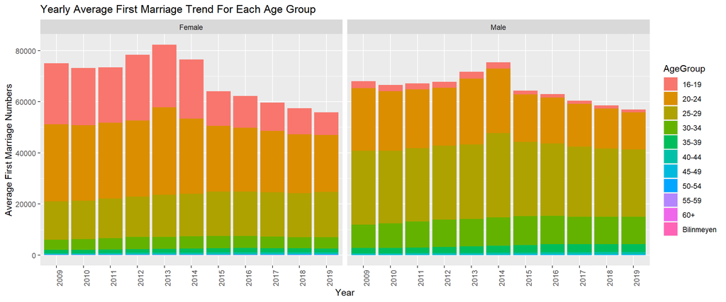

```r
ggplot(age_rawData, aes(x=Year, y=Avg, fill=AgeGroup))+
       geom_col() +
       labs(title="Yearly Average First Marriage Trend For Each Age Group",
            y="Average First Marriage Numbers",
            x="Year") +
            theme(axis.text.x = element_text(angle = 90))+
            facet_wrap(~Gender)
```

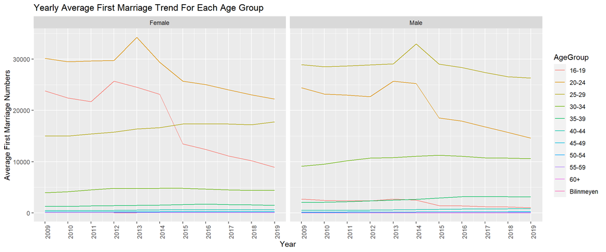

```r
# Line Graph

ggplot(age_rawData, aes(x=as.numeric(Year), y=Avg, color=AgeGroup))+
       geom_line() +
       labs(title="Yearly Average First Marriage Trend For Each Age Group",
            y="Average First Marriage Numbers",
            x="Year") +
            scale_x_continuous(breaks = 2009:2019)+
            theme(axis.text.x = element_text(angle = 90))+
            facet_wrap(~Gender)
```

### Analyze for Education Levels

```r
Edu_rawData<-rawDataOrganized %>%
              group_by(EducationLevel,Year,Gender) %>%
              summarise(Avg=round(mean(NbOfFirstMarriages),digits = 0))

Edu_rawData %>%
  pivot_wider(names_from = Gender, values_from=Avg )%>%
  kbl() %>%
  kable_minimal(full_width = F)
```

| EducationLevel | Year | Female | Male |
| --- | --- | --- | --- |
| Bilinmeyen | 2009 | 5028 | 9789 |
| Bilinmeyen | 2010 | 3973 | 8744 |
| Bilinmeyen | 2011 | 2797 | 6219 |
| Bilinmeyen | 2012 | 2439 | 5701 |
| Bilinmeyen | 2013 | 2032 | 5057 |
| Bilinmeyen | 2014 | 1732 | 4409 |
| Bilinmeyen | 2015 | 763 | 1431 |
| Bilinmeyen | 2016 | 564 | 845 |
| Bilinmeyen | 2017 | 531 | 740 |
| Bilinmeyen | 2018 | 496 | 664 |
| Bilinmeyen | 2019 | 479 | 636 |
| İlkokul | 2009 | 6814 | 9764 |
| İlkokul | 2010 | 5112 | 7587 |
| İlkokul | 2011 | 3660 | 5039 |
| İlkokul | 2012 | 2968 | 4083 |
| İlkokul | 2013 | 2598 | 3377 |
| İlkokul | 2014 | 2082 | 2620 |
| İlkokul | 2015 | 1561 | 1752 |
| İlkokul | 2016 | 2060 | 1501 |
| İlkokul | 2017 | 2350 | 1187 |
| İlkokul | 2018 | 1730 | 929 |
| İlkokul | 2019 | 830 | 693 |
| İlköğretim | 2009 | 16433 | 8480 |
| İlköğretim | 2010 | 18548 | 8541 |
| İlköğretim | 2011 | 16227 | 11096 |
| İlköğretim | 2012 | 16187 | 12444 |
| İlköğretim | 2013 | 18604 | 12352 |
| İlköğretim | 2014 | 20863 | 14966 |
| İlköğretim | 2015 | 14259 | 13043 |
| İlköğretim | 2016 | 12193 | 13738 |

[output cut: 58 more lines]

- The average number of first marriages for women and men that graduated from college has increased throught the years. The reason for this incrase may be due to increasing number of people having bachelor’s or higher degree.
- The average number of first marriages for women that has only elementary school degree is decreased because throught the year more and more women has more than just an elementary degree. As for men, from 2009 to 2014 the average is increased for elementary school educated men, and then it showed an decrease but not as prominent as for women that has same education level.
- The average number of first marriages for both male and women graduated from high school etc. are decreased since people are tend to have higher degree than high school.

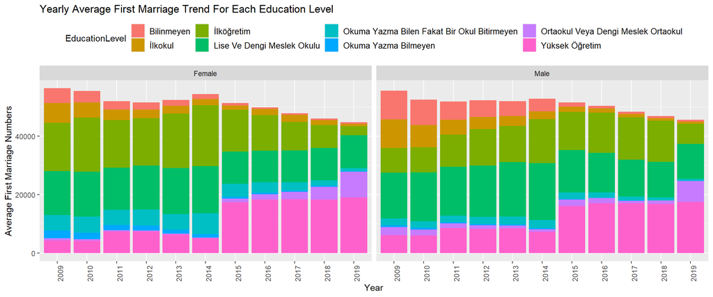

```r
# Bar Graph

ggplot(Edu_rawData, aes(x=Year, y=Avg, fill=EducationLevel))+
       geom_col() +
       labs(title="Yearly Average First Marriage Trend For Each Education Level",
            y="Average First Marriage Numbers",
            x="Year") +
            theme(axis.text.x = element_text(angle = 90),
                  legend.position = "top" ,
                  legend.text=element_text(size=10))+
            facet_wrap(~Gender)
```

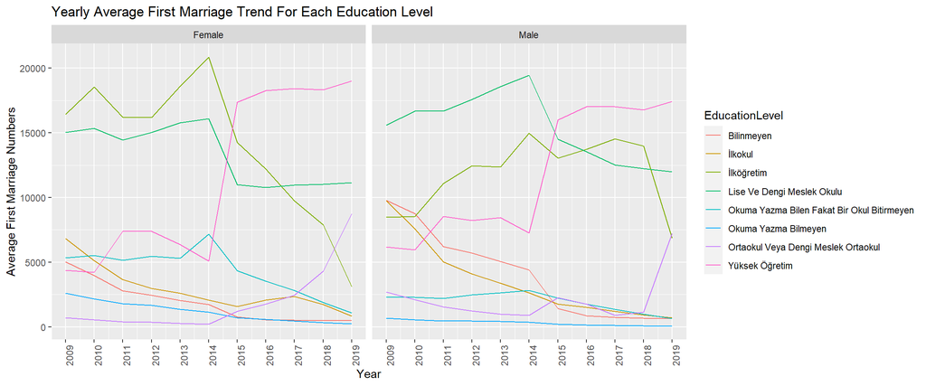

```r
# Line Graph

ggplot(Edu_rawData, aes(x=as.numeric(Year), y=Avg, color=EducationLevel))+
       geom_line() +
       labs(title="Yearly Average First Marriage Trend For Each Education Level",
            y="Average First Marriage Numbers",
            x="Year") +
            scale_x_continuous(breaks = 2009:2019)+
            theme(axis.text.x = element_text(angle = 90))+
            facet_wrap(~Gender)
```

## References

- https://biruni.tuik.gov.tr/medas/?kn=112&locale=tr